# Сообщества Макрозообентоса Обской губы

## Пространственное распределение биомассы и плотности поселения бентосных животных

Для оценки пространственного распределения бентоса Обской губы были построены карты (Рисунок 1). Высокие суммарные биомассы и плотности поселения отмечались в основном в прибрежных районах. Важно отметить и высокие показатели обилия бентоса в районе терминала. Биомасса демонстрирует некоторую связь с глубиной (Рисунок 2, A). Однако эта связь нелинейна: максимальные биомассы отмечаются на средних значениях глубины (10-20 м). Связь суммарной численности организмов с глубиной значительно слабее (Рисунок 2, B). В целом, в пространственном распределении суммарной биомассы и общей плотности просматривается, скорее пятнистый паттерн, чем черты градиента. О пятнистой структуре биоценотического покрова свидетельствует и заметное количество станций, с отскакивающими от общего пула станциями, демонстрирующими чрезвычайно высокие показатели обилия (Рисунок 2).

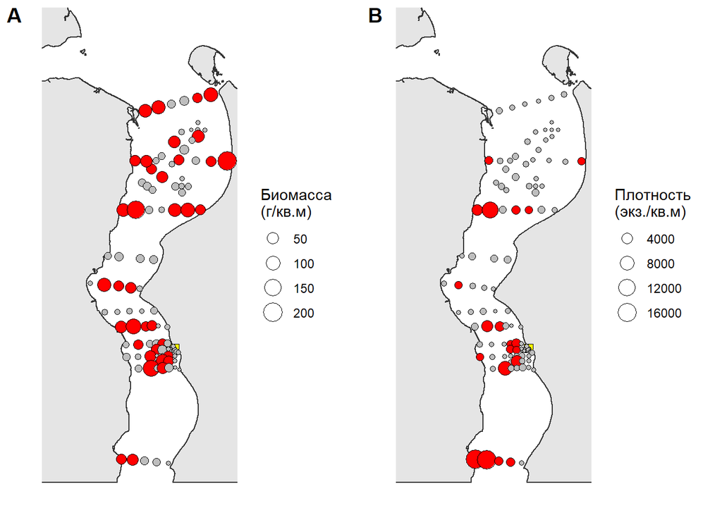

**Рисунок 1.** Пространственное распределение общей биомассы (А) и суммарной плотности поселения (B) бентосных организмов.Размер точек пропорционален обилию на станции. Красные точки - станции, на которых обилие превышает среднее значение.

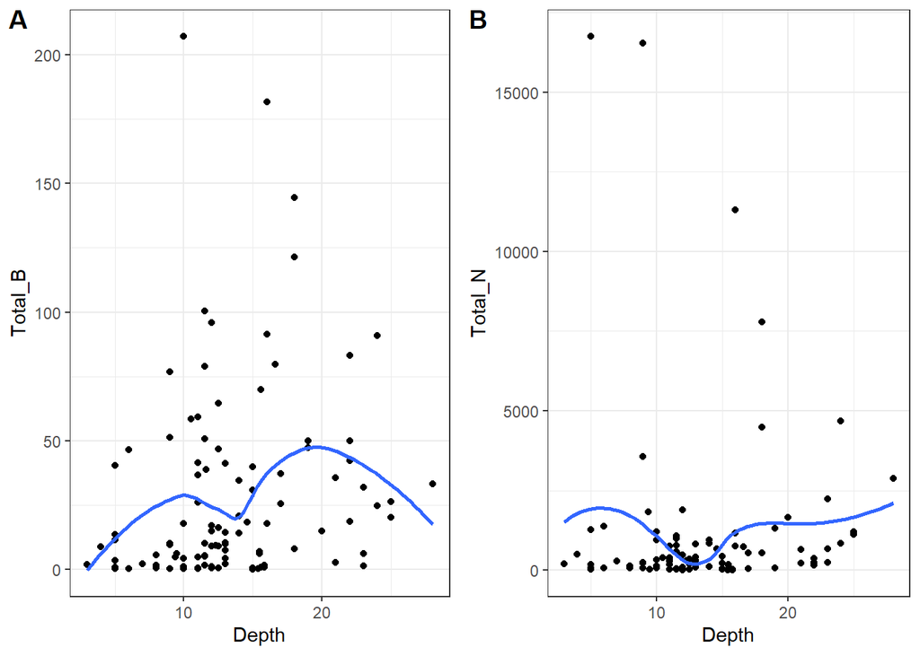

**Рисунок 2.** Связь общей биомассы (А) и суммарной плотности поселения (B) бентосных организмов с глубиной.Линия отражает LOESS регрессию.

# Связь зообентоса с параметрами среды

При рассмотрении всего набора видов зообентоса, включающего 62 вида, канонический корреспондентный анализ показал лишь незначительную роль канонических осей (они описывали лишь единичные проценты суммарной изменчивости). Применение непрямых методов ординации (nMDS) также не позволило достичь приемлемой ординации станций при использовании полного набора видов. Это еще раз подтверждает мозаичный характер распределения бентосных сообществ. В связи с этим была произведена фильтрация видового состава: были отброшены виды, имеющие плотность поселения ниже 500 экз./м<sup>2</sup>. Дальнейший многомерный анализ был проведен с использованием матрицы обилий лишь 16видов.

Канонический корреспонтдентный анализ (ССА) на первом этапе включал все доступные переменные, характеризующие условия среды. Далее было проведено прямое пошаговое упрощение модели, результаты, которой демонстрирует Рисунок 3. Первая каноническая ось, которая описывает 20 % общей изменчивости, традиционно демонстрировала связь с соленостью, разделяя бентосные сообщества на солоновато водные сообщества (отрицательные значения CCA1) и сообщества представленные в опресненной водной массе (положительные значения CCA1).

Ординация видов в пространстве тех же канонических осей (Рисунок 4) позволяет заметить, что к числу видов, характерных для солоноватоводных сообществ, можно отнести следующие таксоны: Ampharete vega , Halicryptus spinulosus, Diastylis sulcata, Pontoporeia femorata, Portlandia aestuariorum.

Более детальное рассмотрение видов, имеющих положительные нагрузки по CCA1 (Рисунок 4), позволяет говорить о существовании трех групп видов. Первая группа представлена олигохетами (*Limnodrilus hoffmeisteri*), тяготеющими к большим глубинам. Вторая группа характеризуется высоким обилием *Sduria entomon* и *Mysis relicta*. Эта группа видов представлена при минимальной солености в водах, богатых азотом. Третья группа включает неопределенных олигохет, остракод и бокоплавов *Monoporeia affinis*, которые тяготеют к малым глубинам в зоне опреснения.

Особое положение занимают *Merenzelleria sp.* и неопределенные сипункулиды, которые имеют нагрузки по CCA1 и CCA2 близкие к нулю, а стало быть распределение этих организмов не подчиняется выявленным градиентам условий.

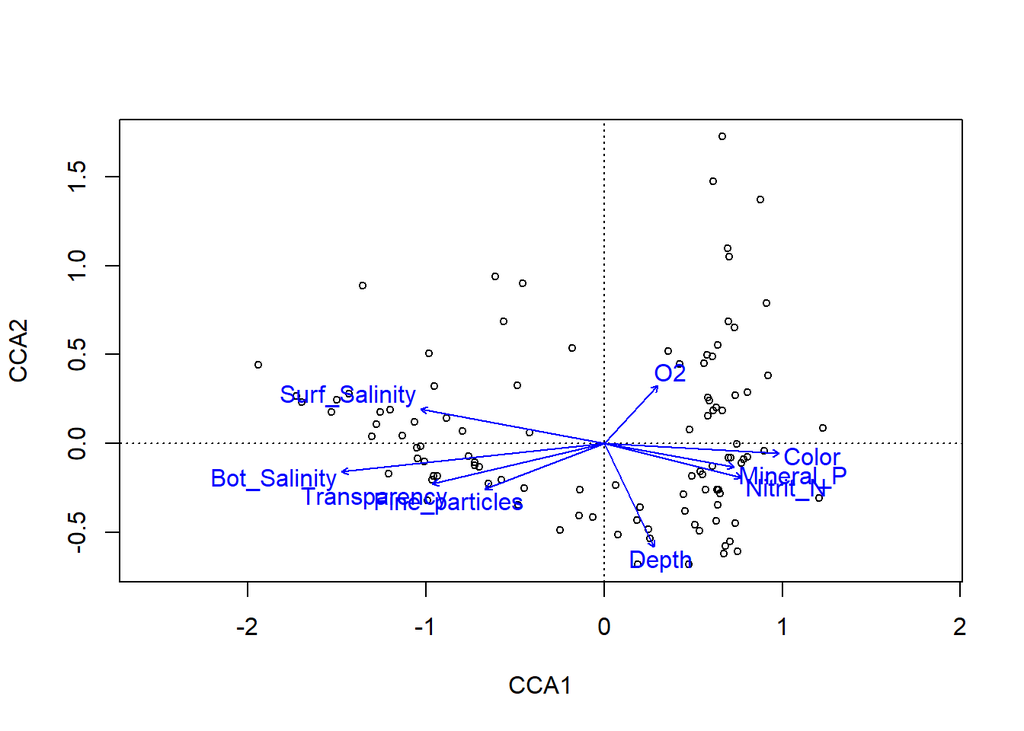

**Рисунок 3.** Ординация станций в канонических корреспондентных осях.

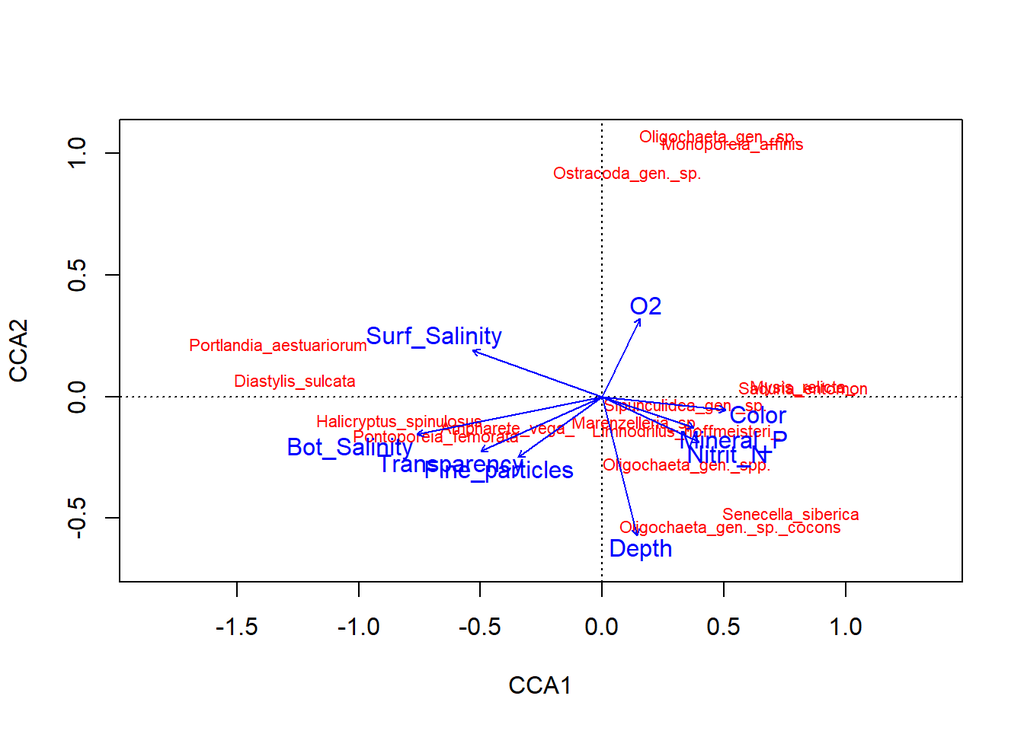

**Рисунок 4.** Ординация видов в канонических корреспондентных осях.

Поскольку визуализация распределения сообществ, как таковых, в столь сложных градиентах малоинформативна ниже приводятся карты, отражающие распределение суммарных обилий видов каждой из описанных групп.

Суммарное обилие видов, тяготеющих к осолоненным водным массам (Рисунок 5) достигает максимума в устьевом участке акватории. Однако в этом районе более низкие значения отмечаются в районах, близких к морскому каналу.

Сообщество олигохет, по всей видимости, приурочено к центральным частям акватории с максимальными глубинами. Вероятно, это сообщество приурочено к локальным ямам и центральному более глубоководному “желобу”, который представлен в центральной части русла.

Сообщество, в котором доминируют *Monoporeia affinis*, *Oligochaeta* и *Ostracoda gen. sp.* демонстрирует заметные обилия только на мелководьях, идущих вдоль западного берега губы.

Самое очевидную трактовку можно дать природе сообщества, в котором доминируют *Saduria entomon*, *Mysis relicta* и *Senecella siberica*. Эта группировка наиболее обильна в непосредственной близости от терминала, где наблюдаются наиболее сильные техногенные воздействия. Вместе с тем, высокое обилие хищников, *Saduria entomon*, связанное с зоной с техногенного нарушения сообществ, вероятно, свидетельствует о переключении питания на какие-то объекты, также связанные с техногенным воздействием. В сходных сообществах Балтийского моря морские тараканы питаются в значительной степени бокоплавами *Monoporeia affinis* (Sparrevik, Leonardsson, 1998; Bergström, Englund, 2002), хотя могут питаться и другими объектами, включая и особей собственного вида. В акватории Обской губы *Monoporeia affinis* избегает разрушенных местообитаний (см. выше).

Возможно кормовую базу для *Saduria entomon* составляют полихеты *Marenzelleria sp.*. В изучаемой акватории самые высокие обилия группа *Marenzelleria sp.*+ Sipunculidea демонстрируют в тех же участках акватории, где наблюдаются максимальные обилия *Saduria entomon*.

Полихеты *Marenzelleria sp.*, представители сем. Spionidae, будучи типичными видами-оппортунистами, демонстрируют экспансию во многих акваториях Северной Атлантики, в том числе и в Балтийском море (Kube et al., 1996; Kauppi et al. 2015), где формируются сообщества очень близкие к сообществам, наблюдаемым в акватории Обской губы. Вспышки обилия видов-оппортунистов характерны для нарушенных местообитаний поэтому вполне ожидаемо эти полихеты оказываются обильными, помимо самого нарушенного местообитания в районе терминала, еще и в районе морского канала. Присутствие этих полихет в большом количестве можно рассматривать как признак нарушенности местообитания.

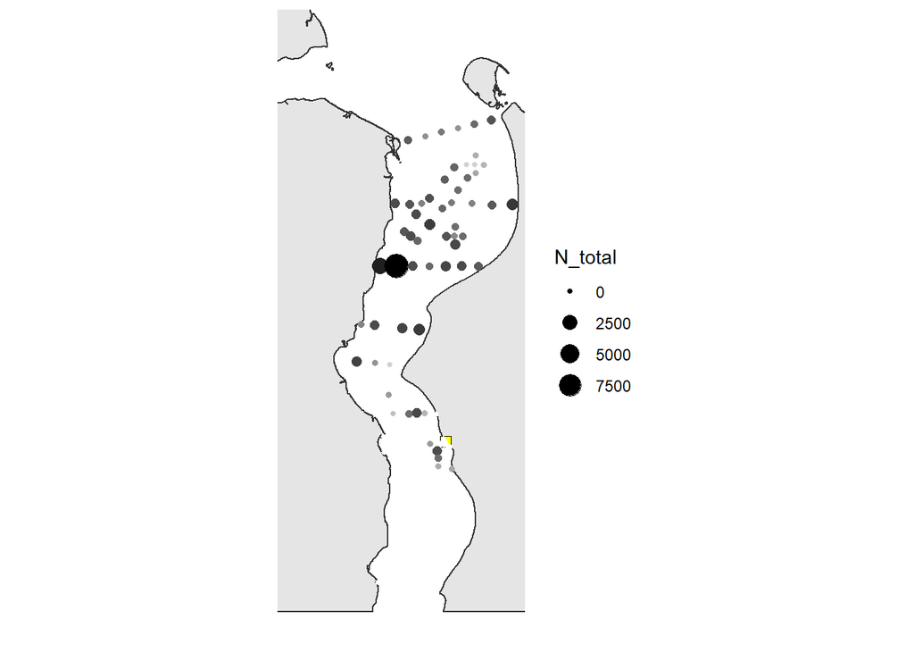

**Рисунок 5.** Суммарное обилие видов, тяготеющих к осолоненным водным массам. Станции с нулевым обилием организмов данной группы не прорисованы.

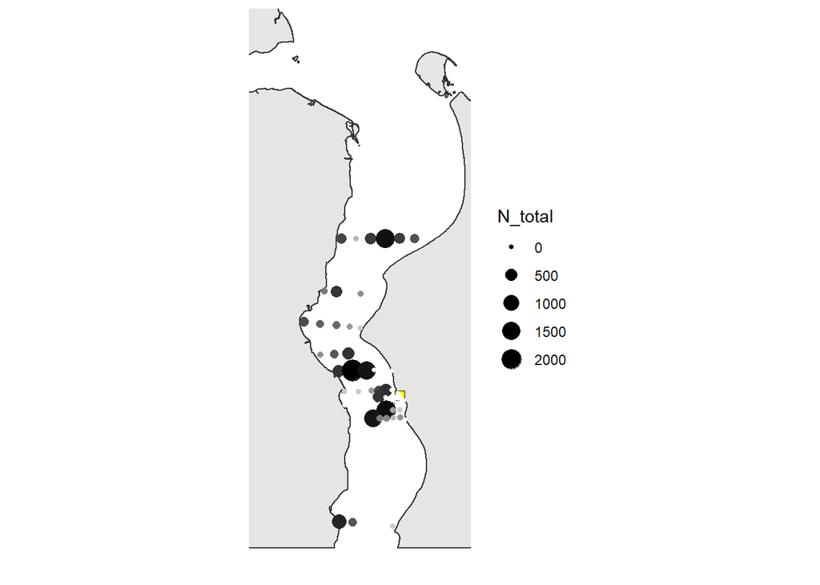

**Рисунок 6.** Суммарное обилие видов сообщества олигохет (*Limnodrilus hoffmeisteri*, *Oligochaeta gen. spp.* Станции с нулевым обилием организмов данной группы не прорисованы.

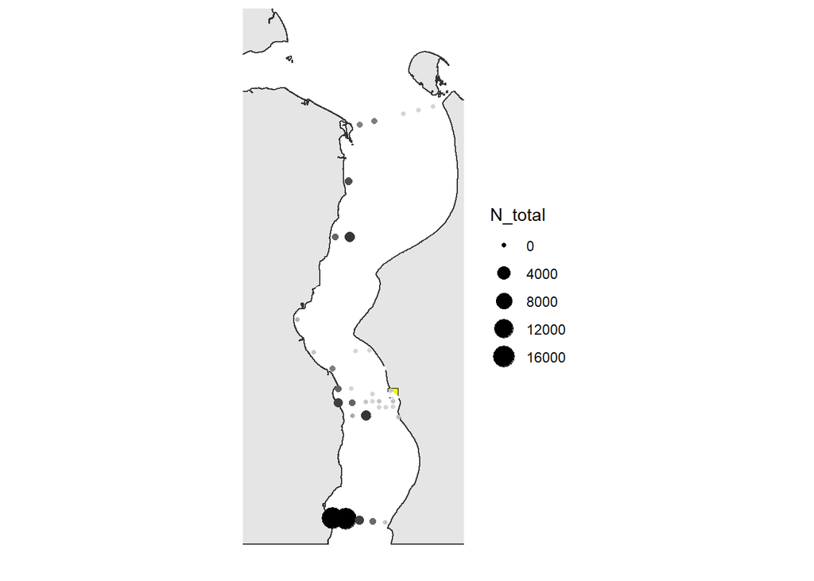

**Рисунок 7.** Суммарное обилие видов сообщества *Monoporeia affinis* + *Oligochaeta* + *Ostracoda gen. sp.* Станции с нулевым обилием организмов данной группы не прорисованы.

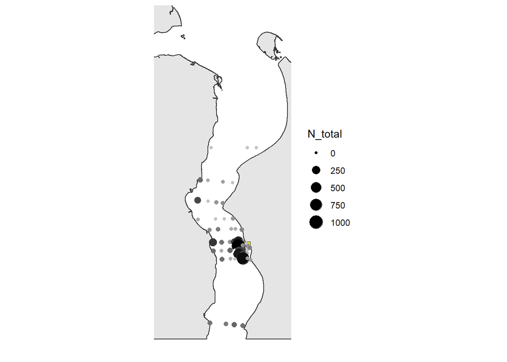

**Рисунок 8.** Суммарное обилие основных видов сообщества *Saduria entomon* + , *Mysis relicta* + *Senecella siberica*. Станции с нулевым обилием организмов данной группы не прорисованы.

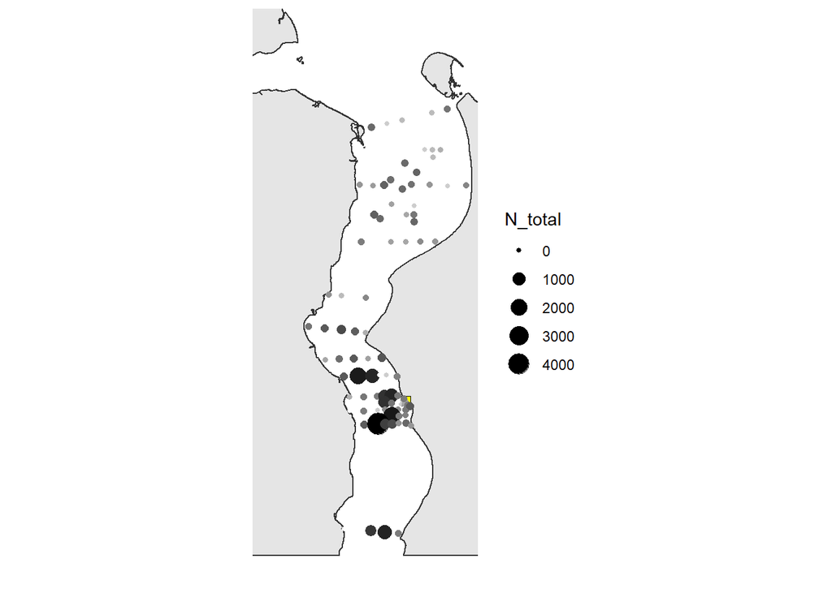

**Рисунок 9.** Суммарное обилие *Marenzelleria sp.* + *Sipunculidea gen. sp.*